# Dodateczek

Witold Merkel

30 - 05 - 2019

# 1 1 Rydelek-Merkel-Stawikowski: wykres Chol od thal

## 1.1 Wykres przed

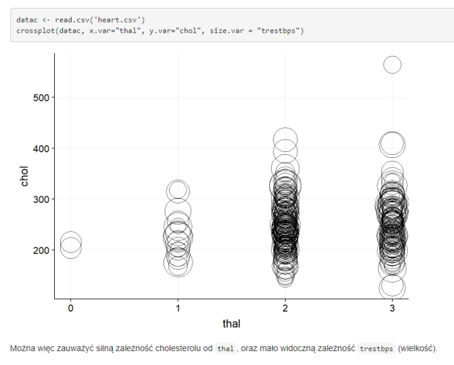

Autor sugeruje, że coś widać na tym wykresie. Ja bym się niekoniecznie zgodził z tym stwierdzeniem.

## 1.2 Wykres po

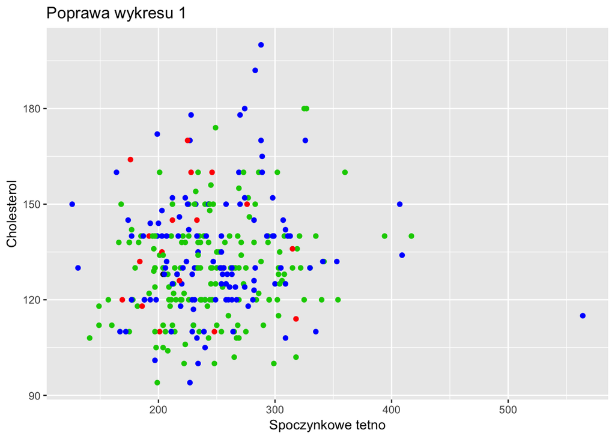

```r
wykres1 <- ggplot(heart, aes(x = trestbps, y = chol)) + geom_point(color = heart$thal) +
  labs(x = 'Cholesterol', y = 'Spoczynkowe tetno', title = 'Poprawa wykresu 1') + coord_flip()
wykres1
```

Tutaj raczej nasuwa się zrobienie osi jako zmiennych ciągłych, a koloru jako zmiennej kategorycznej, bo rozmiary na poprzednim wykresie są nie do odróżnienia.

Kodowanie tej zmiennej nie zgadza się opisem danych na kaggl’u. Kolory przedstawiają się następująco: niebieski kolor reprezentuje naprawionialny defekt serca, zielony to normalne serce, a czerwony tonaprawione serce.

# 2 2 Werner-Jastrzębski-Gajewska: wykres nr 2 w sekcji 3.1

## 2.1 Wykres przed

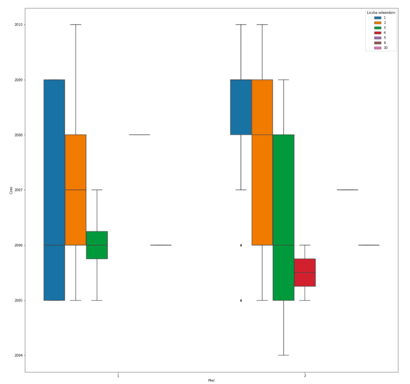

Zupełnie nie wiem o co w tym wykresie chodziło, wykracza to poza moją wyobraźnię.

## 2.2 Wykres po

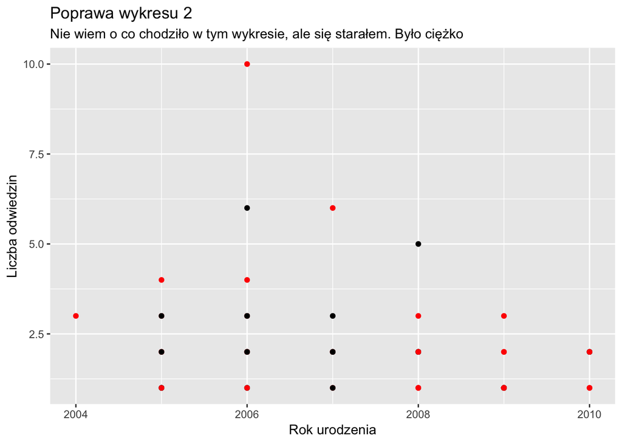

```r
wykres2 <- ggplot(po, aes(x = P1, y = D2)) + geom_point(color = po$D1) + coord_flip() +
  labs(y = 'Rok urodzenia', x = 'Liczba odwiedzin', title = 'Poprawa wykresu 2',
       subtitle = 'Nie wiem o co chodziło w tym wykresie, ale się starałem. Było ciężko')
wykres2
```

Ten wykres zrobił na mnie takie wrażenie, że nawet nie wiem czy to co przedstawiłem na moim wykresie ma sens.

Zależność tego jak liczba odwiedzin zależy od płci(kolor) i roku urodzenia.

# 3 Sprawdzanie symetrii - skośność

Aby sprawdzić to czy rozkład jest symetryczny chciałbym sprawdzić jego skośność. Zastosuje w tej pracy domowej dwa wzory:

- trzeci moment podzielony przed odchylenie standardowe do trzeciej potęgi (ozn. A1),
- (Q3 - 2Med + Q1)/2 (ozn. A2).

Obydwie te metody znam z wykładu ze statystyki, zobaczymy jak się różnią. Artykuły w internecie mówią, że A1 jest lepsze.

Jeżeli skośność wyjdzie w pobliżu zera to znaczy, że rozkłąd jest symetryczny, ujemna skośność znaczy, że jest lewo-skośny, a dodatnia, że jest prawo-skośny.

Skorzystam ze zbioru z mojego projektu, ponieważ te zależności mogą się przydać, a tego nie sprawdzaliśmy. W projekcie robie zbiór `Heart Disease UCI`, który już był wykorzystany w tym zadaniu.

Najpierw trzeba wybrać kolumny liczbowe do tego, a potem można sprawdzać.

```r
data <- select(heart, c('age', "trestbps", "chol", "thalach", "oldpeak"))


skosnoscA1 <- function(x){
  mean((x-mean(x))^3)/(sd(x))^3
}
skosnoscA2 <- function(x){
  (quantile(x, 0.75)-2*median(x)+quantile(x, 0.25))/2
}
A1age <- skosnoscA1(data$age)
A1trestbps <- skosnoscA1(data$trestbps)
A1chol <- skosnoscA1(data$chol)
A1thalach <- skosnoscA1(data$thalach)
A1oldpeak <- skosnoscA1(data$oldpeak)

A2age <- skosnoscA2(data$age)
A2trestbps <- skosnoscA2(data$trestbps)
A2chol <- skosnoscA2(data$chol)
A2thalach <- skosnoscA2(data$thalach)
A2oldpeak <- skosnoscA2(data$oldpeak)

pierwsza <- cbind(A1age, A1trestbps, A1chol, A1thalach, A1oldpeak)
druga <- cbind(A2age, A2trestbps, A2chol, A2thalach, A2oldpeak)

wynik <- rbind(round(pierwsza, 2), round(druga, 2))
colnames(wynik) <- c('age', "trestbps", "chol", "thalach", "oldpeak")
rownames(wynik) <- c("A1", "A2")
```

Przyjrzyjmy się jak to wygląda dla każdej z kolumn.

```r
knitr::kable(data.frame(wynik)) %>%
  kable_styling(bootstrap_options = "striped", full_width = F)
```

|  | age | trestbps | chol | thalach | oldpeak |
| --- | --- | --- | --- | --- | --- |
| A1 | -0.20 | 0.71 | 1.13 | -0.53 | 1.26 |
| A2 | -0.75 | 0.00 | 2.75 | -3.25 | 0.00 |

Tabelka mówi, że age jest lekko lewo-stronny, trestbps jest średnio prawo-skośny, chol jest dość mocno prawo-stornne, thalach jest lekko lewo-stronny i oldpeak dość mocno prawo-skośny.

Zobaczmy gęstości tych zmiennych i zweryfikujmy czy nasze statystyki dobrze mówią.

## 3.1 age

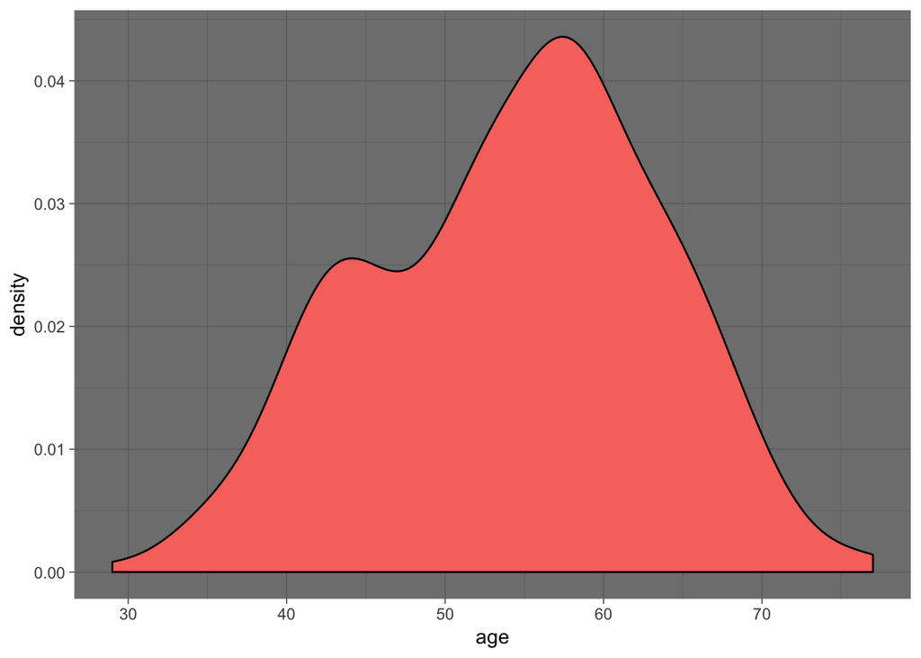

```r
ggplot(data, aes(x = age)) +
  geom_density(aes(y=..density.., fill = 'blue')) + theme_dark() + theme(legend.position="none")
```

## 3.2 trestbps

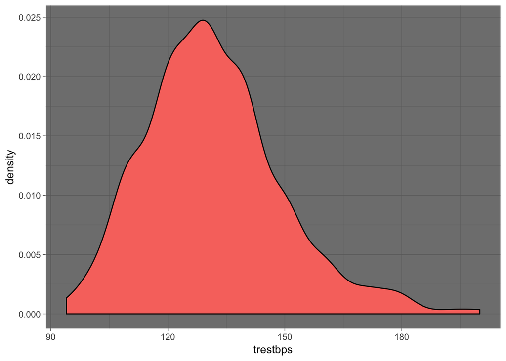

```r
ggplot(data, aes(x = trestbps)) +
  geom_density(aes(y=..density.., fill = 'blue')) + theme_dark() + theme(legend.position="none")
```

## 3.3 chol

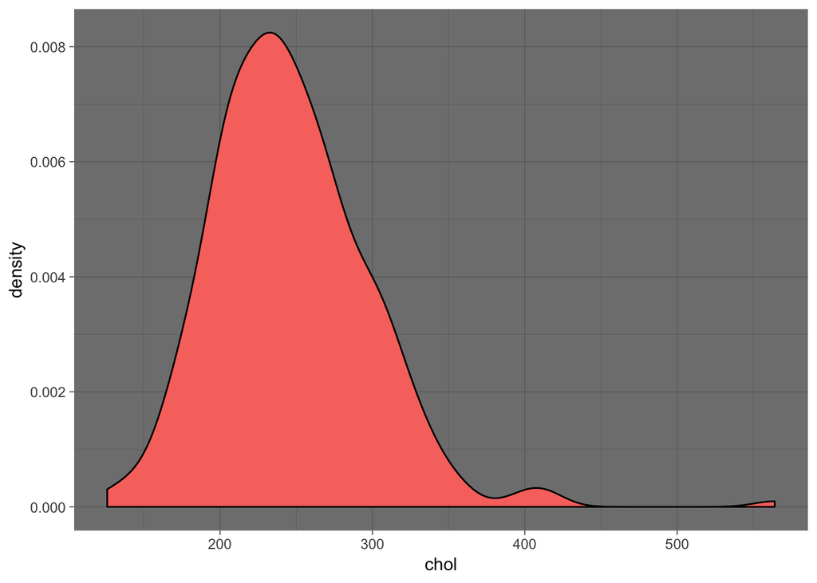

```r
ggplot(data, aes(x = chol)) +
  geom_density(aes(y=..density.., fill = 'blue')) + theme_dark() + theme(legend.position="none")
```

## 3.4 thalach

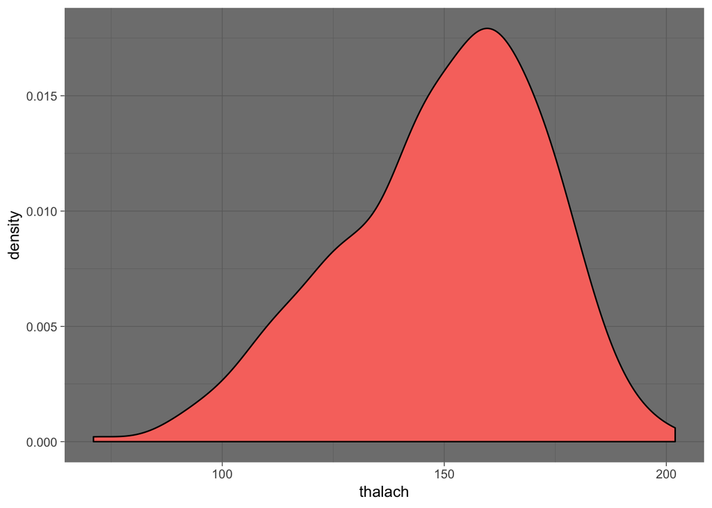

```r
ggplot(data, aes(x = thalach)) +
  geom_density(aes(y=..density.., fill = 'blue')) + theme_dark() + theme(legend.position="none")
```

## 3.5 oldpeak

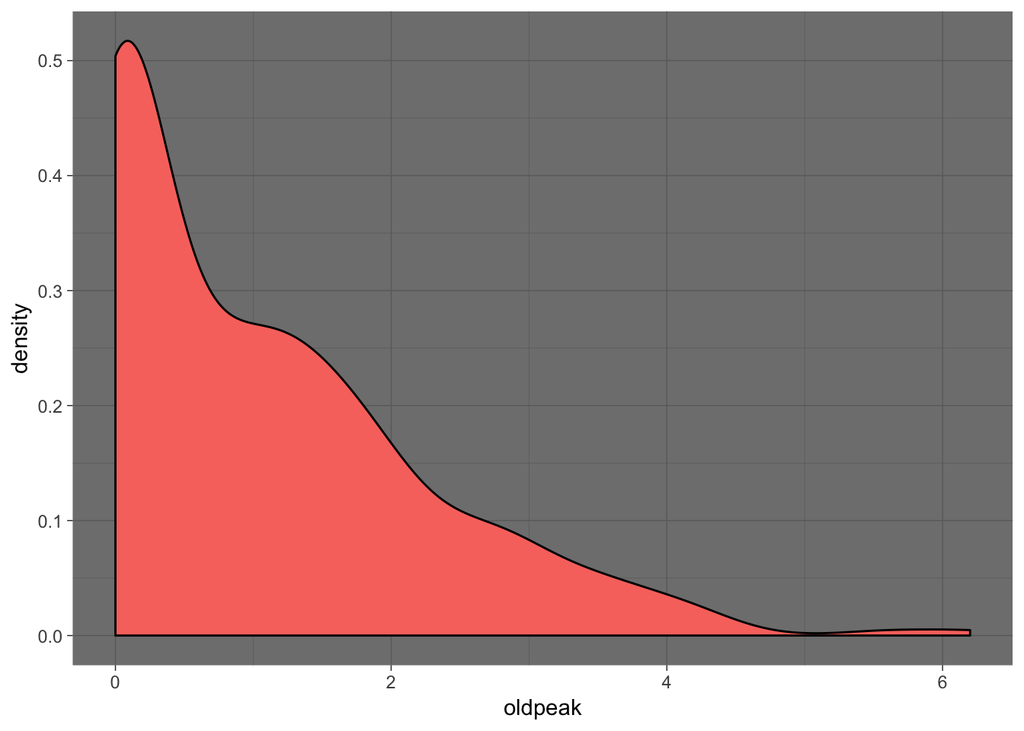

```r
ggplot(data, aes(x = oldpeak)) +
  geom_density(aes(y=..density.., fill = 'blue')) + theme_dark() + theme(legend.position="none")
```

## 3.6 Podsumowanie

Nasza hipoza odnośnie skośności wszystkich zmiennyc sprawdziła się, zatem jest wylicznie `A1` to dobry sposób na sprawdzanie symetrii.

Widać, że statystka `A1` lepiej pokrywa się z prawdą, bo `A2` zwraca w dwóch pzypadkach, że rozkłady są symetryczne jak takie nie są.